# Homework #8

Julia Barrone

11/21/2020

To start with, let’s warm up with a simple one-way ANOVA model. This example, from Whitlock and Schluter chapter 15 question 22 looks at the mass of lodgepole pinecones from different habitats.

1.1. Load and plot the data. Choose a plot that not only shows the raw data, but also the means and SE or CI of those means. +1 EC if Michael thinks it’s fancy.

```
## No summary function supplied, defaulting to `mean_se()`
```

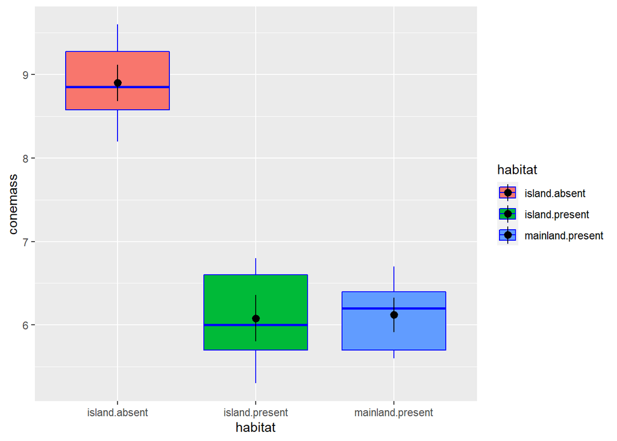

```r
#load libraries that I need
library(ggplot2)
library(dplyr)
library(ggdist)
library(Rmisc)
library(profileModel)
library(car)
library(brms)
library(ggpmisc)
library(emmeans)
library(ggdist)
library(Rmisc)
library(loo)
library(tidyr)
library(rsample)
library(boot)
library(modelr)
library(bayesplot)
library(tidybayes)
#load in data
pinecones <- read.csv("15q22LodgepolePineCones.csv")


#plotting showing mean and standard error
ggplot(data = pinecones,
       mapping = aes(x=habitat,
                     y=conemass,
                     fill = habitat))+
    geom_boxplot(color="blue")+
    stat_summary()
```

1.2 Fit a model using least squares and evaluate all relevant assumptions. List them out as you test them. Can we use this model? If not, fix it. But if we can, no fix is needed!

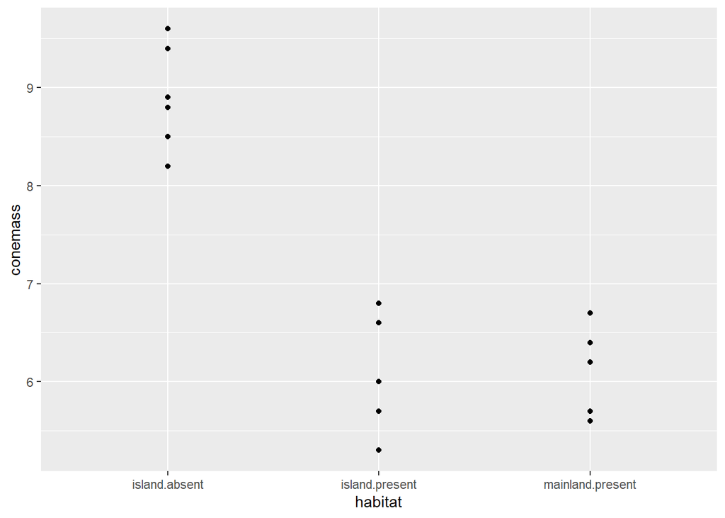

```r
#finding the linear model of the pinecone data, this provides us the intercept and slopes
pine_mod_lm <- lm(conemass ~ habitat, data = pinecones)

#            (Intercept)    habitatisland.present
#                   8.90                    -2.82
#habitatmainland.present
#                  -2.78

#visualizing data with ggplot
pine_plot <- ggplot(data=pinecones, aes(x= habitat, y=conemass)) +
  geom_point()

#viewing plot to see relationship. notable difference in conemass in island absent
pine_plot
```

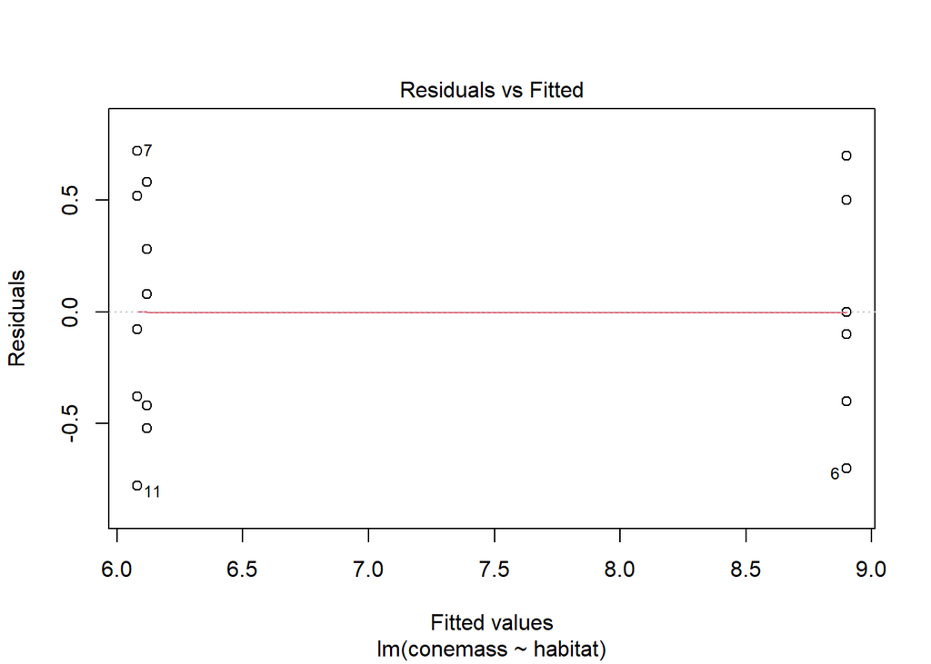

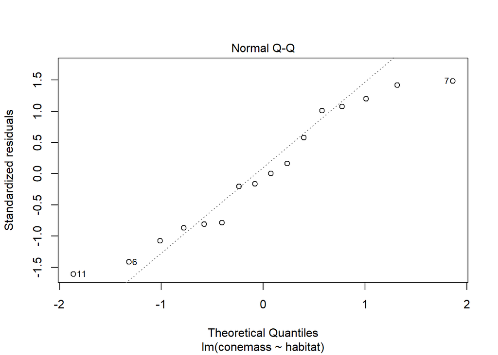

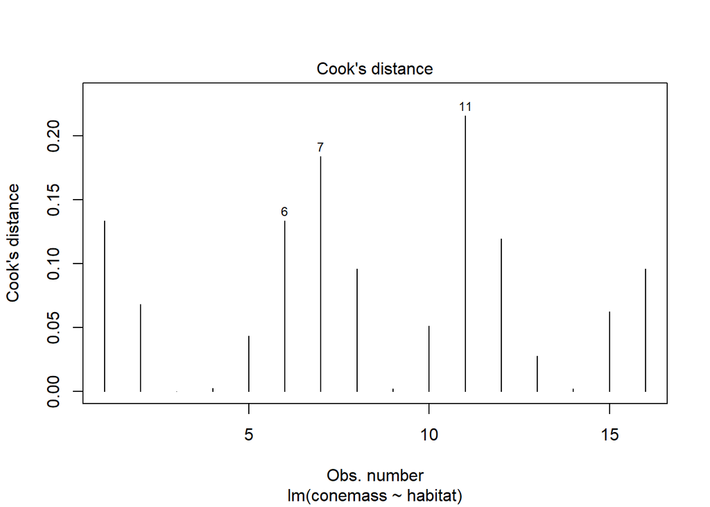

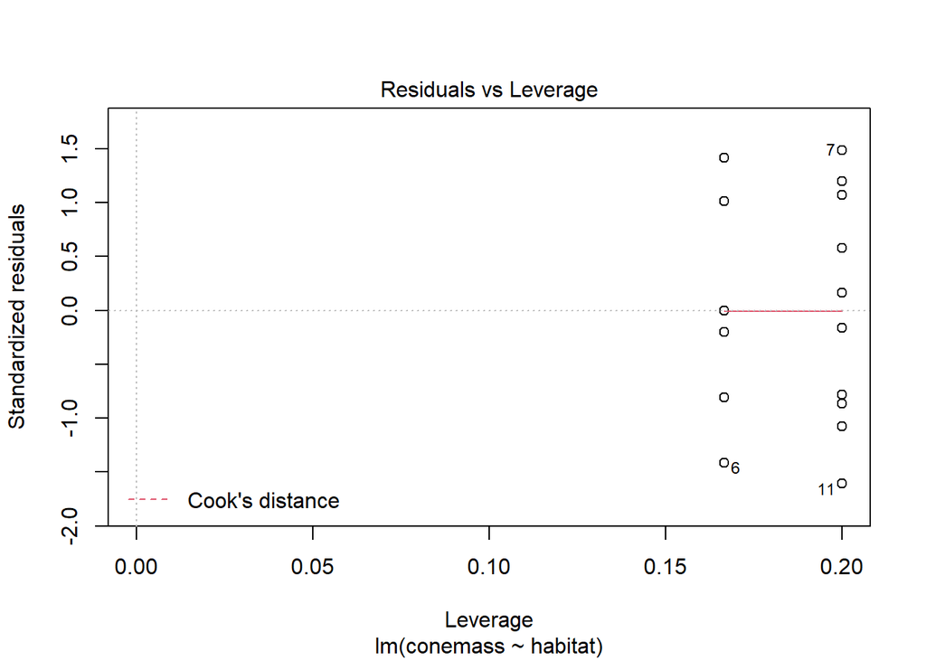

```r
#testing assumptions
plot(pine_mod_lm, which=c(1,2,4,5))
```

```r
#residual vs fitted plot is ok because looking at groups, and the QQplot is a bit off and doesn't follow the straight line well
#cook's distance looks good, not a lot of leverage

#f-tests of model
anova(pine_mod_lm)
```

```
## Analysis of Variance Table
##
## Response: conemass
##           Df Sum Sq Mean Sq F value    Pr(>F)
## habitat    2 29.404 14.7020  50.085 7.787e-07 ***
## Residuals 13  3.816  0.2935
## ---
## Signif. codes:  0 '***' 0.001 '**' 0.01 '*' 0.05 '.' 0.1 ' ' 1
```